# EXERCIE

SAIKOU

2024-11-25

# CLASSIFICATION AVEC ALGORITHM KMEANS

### Mon Repertoire de Travail

```r
setwd("C:/Users/Saikou/Desktop/3/DATA")
```

## Importation des données et visualisation :

```r
vt <- read.delim("voitures", sep="")
```

```r
#Nombres de lignes
nrow(vt)
```

```
## [1] 20
```

```r
#Structure de ma base de données
str(vt)
```

```
## 'data.frame':    20 obs. of  8 variables:
##  $ CYL    : int  875 999 1199 2995 1997 2993 898 1995 898 1995 ...
##  $ PUIS   : int  105 95 130 340 160 256 90 116 90 136 ...
##  $ LON    : int  406 397 442 447 428 483 406 462 406 447 ...
##  $ LAR    : int  172 174 182 192 184 191 173 181 173 185 ...
##  $ POIDS  : int  1130 1065 1280 1587 1370 2570 1092 1570 962 1751 ...
##  $ VITESSE: int  184 186 196 260 220 180 182 198 175 184 ...
##  $ ACCEL  : num  11.4 10.9 10.1 5.7 8.2 9.3 12.2 11.1 11.1 10.9 ...
##  $ CO2    : int  98 103 115 234 130 203 105 109 116 139 ...
```

Dans notre base de données, nous avons 8 variables indépendantes qui représentent les caractéristiques de chaque marque. Nous constatons que ces variables ne sont pas exprimées dans la même unité de mesure. Il est important de résoudre ce problème, car l’algorithme k-means est sensible aux différences d’unités entre les variables.

```r
#Quelques statistiques descriptives}
summary(vt)
```

```
##       CYL            PUIS            LON             LAR            POIDS
##  Min.   : 875   Min.   : 69.0   Min.   :272.0   Min.   :163.0   Min.   : 905
##  1st Qu.:1149   1st Qu.:102.5   1st Qu.:406.0   1st Qu.:174.8   1st Qu.:1168
##  Median :1995   Median :133.0   Median :443.5   Median :181.5   Median :1465
##  Mean   :2116   Mean   :181.6   Mean   :432.4   Mean   :182.2   Mean   :1497
##  3rd Qu.:2343   3rd Qu.:177.8   3rd Qu.:464.5   3rd Qu.:191.2   3rd Qu.:1728
##  Max.   :6262   Max.   :660.0   Max.   :522.0   Max.   :200.0   Max.   :2570
##     VITESSE          ACCEL            CO2
##  Min.   :160.0   Min.   : 4.10   Min.   : 98.0
##  1st Qu.:181.5   1st Qu.: 9.15   1st Qu.:112.0
##  Median :192.5   Median :10.80   Median :134.0
##  Mean   :203.2   Mean   : 9.95   Mean   :156.1
##  3rd Qu.:209.0   3rd Qu.:11.43   3rd Qu.:156.5
##  Max.   :335.0   Max.   :13.70   Max.   :380.0
```

## Algorithme K-means

C’est une méthode de clustering non supervisée qui permet de regrouper des données similaires. Elle nous permet de former K clusters distincts à partir de nos observations, ainsi on aura un regroupement des données similaires au sein d’un même cluster.

### Representation Graphique

#### Verification des Valeurs Aberantes

Dans notre base de données, on constate une absence de données manquantes . Néamoins, il est important de verifier la présence de valeurs aberrantes, car l’algorithme est sensible à ces valeurs. La présence de valeurs aberrantes pourrait influencer les centres des clusters et donc directement impacter la qualité de notre partionnement.

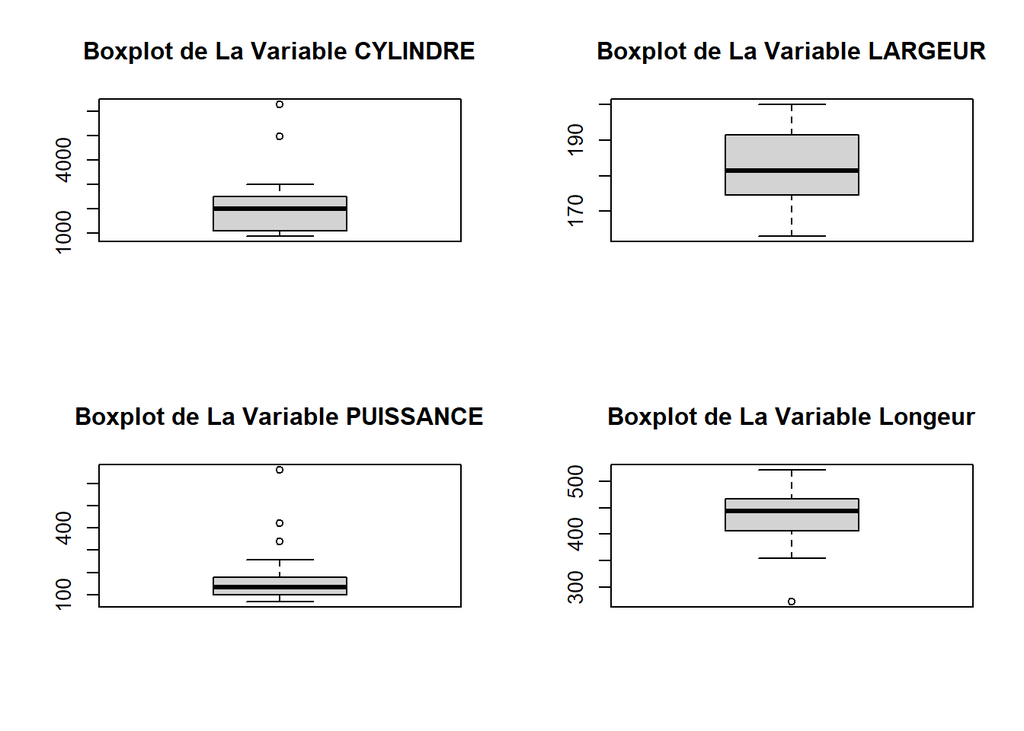

```r
par(mfrow=c(2, 2))

# Créez des boxplots pour différentes variables
boxplot(vt$CYL, main="Boxplot de La Variable CYLINDRE")
boxplot(vt$LAR, main="Boxplot de La Variable LARGEUR")
boxplot(vt$PUIS, main="Boxplot de La Variable PUISSANCE")
boxplot(vt$LON, main="Boxplot de La Variable Longeur")
```

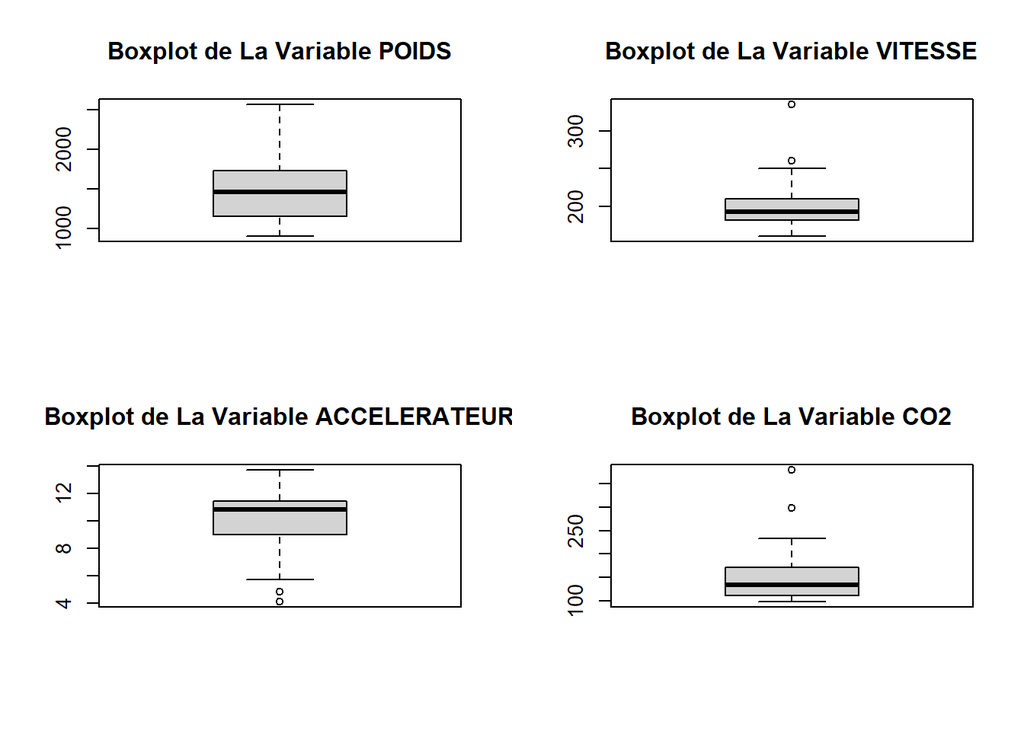

```r
par(mfrow=c(2, 2))
boxplot(vt$POIDS, main="Boxplot de La Variable POIDS")
boxplot(vt$VITESSE, main="Boxplot de La Variable VITESSE")
boxplot(vt$ACCEL, main="Boxplot de La Variable ACCELERATEUR")
boxplot(vt$CO2, main="Boxplot de La Variable CO2")
```

On constate la presence de valeurs aberrantes pour plusieurs de nos variables, cela pourrait avoir des répercussions sur les centres des clusters ainsi que sur la distance euclidienne utilisée par notre algorithme. elles risquent également de biaiser le choix optimal de nos clusters. Pour résoudre ce problème, une solution consiste à effectuer une transformation logarithmique. Toutefois, nous allons travailler sur nos données brutes.

#### Matrice de Corrélation

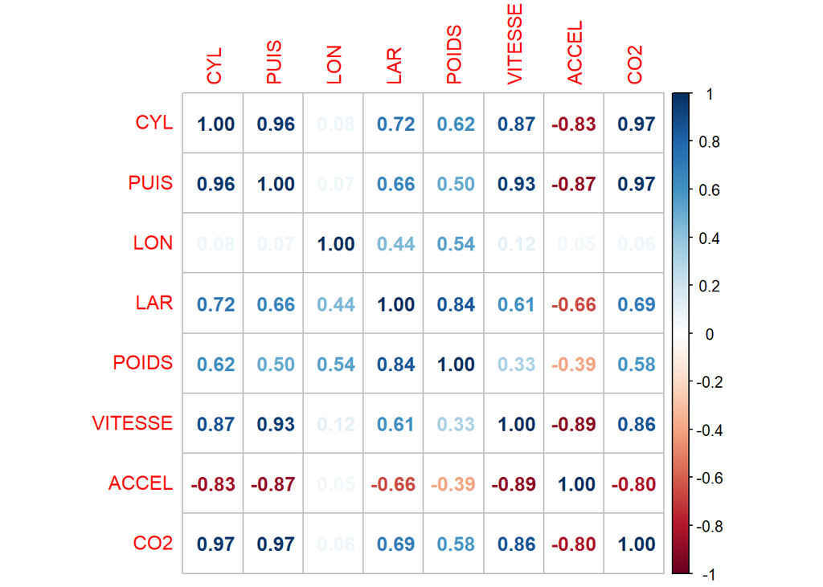

```r
#Matrice
vt_numerique <- vt[sapply(vt, is.numeric)]
library(corrplot)
matrice_correlation <- cor(vt_numerique)
corrplot(matrice_correlation, method="number")
```

Nous constatons une corrélation de 0,96 entre le nombre de cylindres d’une voiture et sa puissance, cela suggere une forte corrélation positive entre ces deux variables. Cela signifie qu’en général, lorsque le nombre de cylindres augmente, la puissance du véhicule a tendance à augmenter également. On a une corrélation similaire qui existe entre le nombre de cylindres et les émissions de CO2, suggérant que les véhicules avec un nombre plus élevé de cylindres ont tendance à émettre davantage de CO2.

Cependant, une corrélation de -0,83 est observée entre le nombre de cylindres et l’accélération (temps nécessaire pour atteindre 100 km/h). Ainsi, les véhicules avec un nombre plus élevé de cylindres ont tendance à avoir un temps d’accélération plus court.

Il est essentiel de visualiser ces corrélations, car une forte corrélation peut introduire une redondance, ce qui entraîne une attribution de poids excessive par notre algorithme aux variables fortement corrélées.

```r
#Variance des mes variables
# Je definis la liste des colonnes que je veux utiliser
c <-c("CYL","PUIS","LON","LAR","POIDS","VITESSE","ACCEL","CO2")
# Je calcul la variance pour chaque colonne
variances <- round(sapply(vt[c], var),2)
# Affichage
tableau<- data.frame(Variable = names(variances), Variance = variances)
print(tableau)
```

```
##         Variable   Variance
## CYL          CYL 1931706.34
## PUIS        PUIS   20529.31
## LON          LON    2894.79
## LAR          LAR      90.09
## POIDS      POIDS  187162.33
## VITESSE  VITESSE    1566.48
## ACCEL      ACCEL       6.91
## CO2          CO2    5509.94
```

Nous constatons que la variance de chaque variable est non nulle, ce qui est positif. Neamoins, il est important de noter que les variances different enormement. Les variables avec des variances plus élevées auront un impact plus significatif sur la mesure de la distance dans nos analyses.

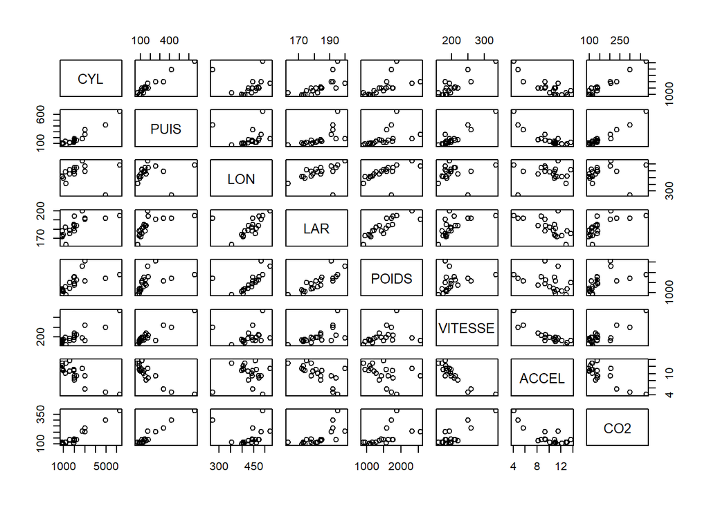

```r
#Nuages par pairs
pairs(vt)
```

L’objectif de cette étape est de visualiser les relations entre différentes variables afin de détecter d’éventuels clusters naturels, des regroupements potentiels de points qui presentent des tendances similaires. Par exemple, quand on examine la variable CO2, nous identifions clairement cinq observations qui se distinguent des autres, une observation similaire est également notée pour la variable puissance. Cependant, avec la variable longueur, la détection de tels regroupements devient plus complexe. Lorsqu’on a un grand nombre de variables , l’analyse visuelle des relations devient difficile à l’œil nu. C’est pourquoi il est essentiel d’utiliser un algorithme pour une analyse plus approfondie.

### Modification des données

Comme l’algorithme repose sur la mesure des distances et que nos variables ont des unités différentes, cela risque de biaiser nos résultats. Afin d’éviter ce problème, on standardise les variables pour les ramener à une échelle commune. Cette démarche contribue à rendre l’algorithme plus cohérent et améliore l’interprétation des résultats de clustering.

```r
#Moyenne de mes variables
print(colMeans(vt))
```

```
##     CYL    PUIS     LON     LAR   POIDS VITESSE   ACCEL     CO2
## 2116.35  181.60  432.45  182.25 1496.70  203.20    9.95  156.05
```

Nous constatons des valeurs moyennes très differentes, indiquant que nos variables sont mesurées dans des unités différentes. Lors de l’application de l’algorithme, les variables avec une variance élevée auront une influence trés élevée sur les résultats.

#### Standardisation

```r
#Standardisation
vt_stan<-scale(vt)
head(vt_stan)
```

```
##                    CYL       PUIS        LON         LAR      POIDS    VITESSE
## ALPHAMITO  -0.89314855 -0.5346156 -0.4916062 -1.07989243 -0.8476210 -0.4851078
## AUDIA1     -0.80393082 -0.6044088 -0.6588825 -0.86918171 -0.9978674 -0.4345757
## CITROENC4  -0.66003127 -0.3601327  0.1774987 -0.02633884 -0.5008985 -0.1819154
## JAGUARF     0.63218671  1.1055237  0.2704299  1.02721475  0.2087270  1.4351104
## PEUGEOTRCZ -0.08587206 -0.1507532 -0.0827088  0.18437188 -0.2928649  0.4244693
## LANDROVER   0.63074771  0.5192611  0.9395348  0.92185939  2.4809152 -0.5861719
##                  ACCEL        CO2
## ALPHAMITO   0.55169004 -0.7820393
## AUDIA1      0.36145210 -0.7146802
## CITROENC4   0.05707138 -0.5530183
## JAGUARF    -1.61702254  1.0501286
## PEUGEOTRCZ -0.66583281 -0.3509410
## LANDROVER  -0.24730933  0.6325021
```

#### Determination des Clusters

Il est difficile de choisir un nombre de cluster intuitivement,La strategie simple est de faire evoluer le nombre de classes et surveiller l’evolution de l’inertie intra-classes. Dans notre cas, on observe une augmentation significative jusqu’à 0.49(classe2), le reste des augmentations est moins importantes, comme dans l’analyse k-means nous recherchons le point ou l’augmentation ralentit , considéré comme le point optimal pour le nombre de classes. On pourrait aussi etre tenter de dire qu’on à plutôt deux solutions, une solution à 2 classes ou 3.

```r
a <-c()
niveaux_cluster <- c()
for (k in 1:8){
  t<-kmeans(vt_stan,centers=k)
  a[k]<-round(t$betweenss/t$totss,digits=2)
  niveaux_cluster[k] <- k
}
resultats <- data.frame(Nombredecluster = niveaux_cluster ,Inertie = a)
print(resultats)
```

```
##   Nombredecluster Inertie
## 1               1    0.00
## 2               2    0.49
## 3               3    0.69
## 4               4    0.78
## 5               5    0.86
## 6               6    0.91
## 7               7    0.90
## 8               8    0.94
```

Une autre méthode couramment utilisée est la méthode du coude (Elbow Method), qui repose sur une approche graphique. Pour chaque valeur de k, on mesure la somme des carrés des distances intra-cluster, puis on trace le graphique. Le point du coude, représente le nombre de clusters à partir duquel la réduction de la variance n’est plus significative. C’est ce point qui est généralement choisi comme nombre optimal de clusters.

```r
#Methode du coude
library(factoextra)
```

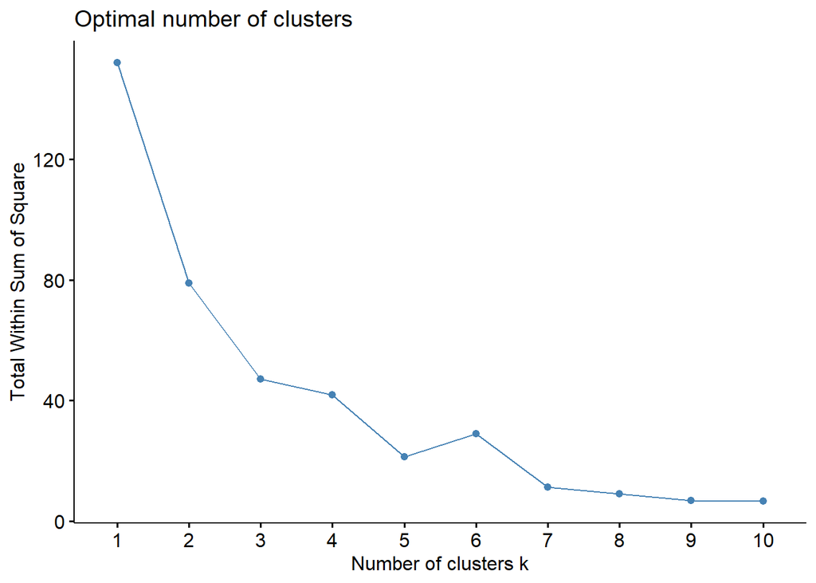

```r
result <- fviz_nbclust(vt_stan, FUNcluster = kmeans, method = "wss")
# résultats
print(result)
```

Ici, le point du coude identifié est au nombre de clusters = 3, avec une chute significative de la courbe entre 1 et 3. Néamoins, l’interprétation peut varier entre différentes personnes. Une autre méthode est l’utilisation du score de silhouette pour évaluer la qualité des clusters, qui varie entre [-1, 1]. On considère la valeur de “k” ayant le score de silhouette le plus proche de 1 comme le nombre optimal de clusters.

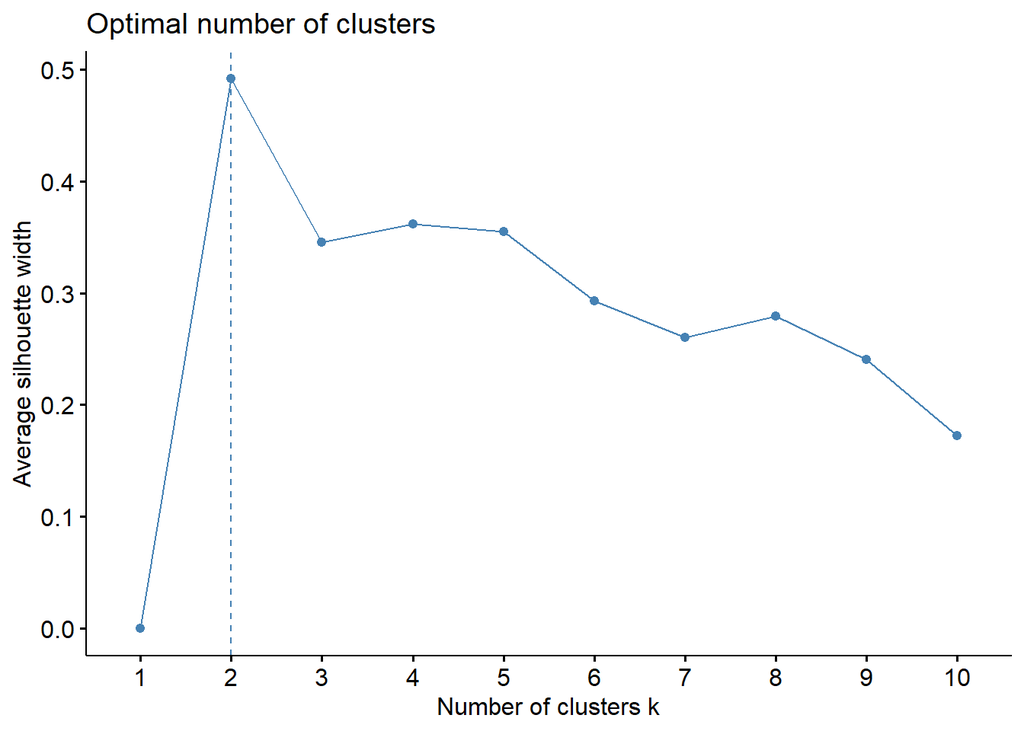

```r
library(factoextra)
# basé sur la minimisation de la somme des carrees des ecarts à l'interieur des clsuters
# la méthode de la silhouette pour k-means
result <- fviz_nbclust(vt_stan, FUNcluster = kmeans, method = "silhouette")
# Les resultats
print(result)
```

Les deux méthodes fournissent des résultats divergents. La méthode de la silhouette, qui mesure la qualité de la séparation entre les clusters, suggère un nombre optimal de clusters égal à 2. Dans ce cas, nous allons prendre en compte les deux suggestions et évaluer la pertinence des clusters générés pour chaque configuration (2 et 3 clusters) afin de prendre une décision éclairée.

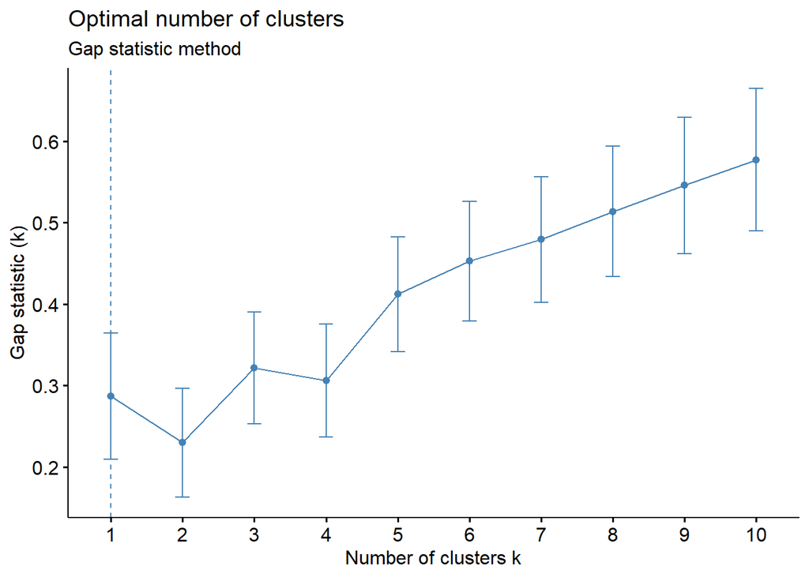

```r
set.seed(123)
fviz_nbclust(vt_stan, kmeans, nstart = 14, method = "gap_stat", nboot = 500)+
labs(subtitle = "Gap statistic method")
```

Cette méthode suggère un cluster optimal avec k=1, ce qui pourrait indiquer que la structure de nos données est homogène et ne justifie pas la création de clusters. La statistique du gap compare la dispersion intra-cluster réelle avec celle générée aléatoirement.

#### Procédure K-Means

L’algorithme k-means est un processus itératif visant à minimiser la somme des distances entre chaque observation et le centroïde. Pour un debut, nous fixons le nombre de clusters à k=2.

```r
set.seed(123)
km<-kmeans(vt_stan,centers=2,nstart=40000)
print(km)
```

```
## K-means clustering with 2 clusters of sizes 17, 3
##
## Cluster means:
##          CYL       PUIS         LON        LAR       POIDS    VITESSE
## 1 -0.3326175 -0.3597222  0.09550051 -0.1998653 -0.09475722 -0.3498602
## 2  1.8848323  2.0384256 -0.54116956  1.1325701  0.53695760  1.9825411
##        ACCEL        CO2
## 1  0.3413093 -0.3525259
## 2 -1.9340858  1.9976469
##
## Clustering vector:
##     ALPHAMITO        AUDIA1     CITROENC4       JAGUARF    PEUGEOTRCZ
##             1             1             1             2             1
##     LANDROVER   RENAULTCLIO         BMWS3         DACIA       HYUNDAI
##             1             1             1             1             1
##        LANCIA RENAULTCAPTUR   FORDMUSTANG       FIAT500         HONDA
##             1             1             2             1             1
##       FERRARI        SUBARU         MAZDA    VOLKSWAGEN    JAGUARPACE
##             2             1             1             1             1
##
## Within cluster sum of squares by cluster:
## [1] 57.11066 19.94784
##  (between_SS / total_SS =  49.3 %)
##
## Available components:
##
## [1] "cluster"      "centers"      "totss"        "withinss"     "tot.withinss"
## [6] "betweenss"    "size"         "iter"         "ifault"
```

L’algorithme k-means a formé 2 clusters, le premier avec 17 Marques et le second avec 3 marques. A travers la moyenne des clusters on obtient pour chaque classe la moyenne des variables de nos observations, si on regarde plus en detail, on observe que Les voitures du Cluster 1 ont quelques caractéristiques spécifiques. En moyenne, elles sont :

- Plus longues que la moyenne.
- Moins larges que la moyenne.
- Un nombre de cylindres légèrement inférieur à la moyenne.
- Une puissance légèrement inférieure à la moyenne.
- Une vitesse légèrement inférieure à la moyenne.
- Une accélération légèrement plus élevée que la moyenne.
- Émettent légèrement moins de CO2 que la moyenne.

Les voitures du Cluster 2 ont quelques caractéristiques spécifiques. En moyenne, elles sont :

- Plus de cylindres que la moyenne.
- Avec une puissance plus élevée que la moyenne.
- Plus courtes que la moyenne.
- Plus larges que la moyenne.
- Plus lourdes que la moyenne.
- Avec une vitesse plus élevée que la moyenne.
- Avec une accélération nettement inférieure à la moyenne.
- Émettant nettement plus de CO2 que la moyenne.

Le vecteur de clustering indique à quel cluster chaque observation appartient. Au sein du cluster 2, on a les marques suivantes : FERRARI JAGUARF FORDMUSTANG. On a donc dans ce cluster des voitures de sport avec des caracteristques: cylindrées élevées, une puissance importante, une accélération rapide et des émissions de CO2 relativement élevées peuvent être regroupées ensemble. La qualité du partitionnement est de 49,3%.

```r
set.seed(123)
km1<-kmeans(vt_stan,centers=3,nstart=1)
print(km1)
```

```
## K-means clustering with 3 clusters of sizes 3, 8, 9
##
## Cluster means:
##           CYL       PUIS        LON        LAR      POIDS    VITESSE
## 1  1.88483231  2.0384256 -0.5411696  1.1325701  0.5369576  1.9825411
## 2  0.09184389 -0.1141118  0.6328617  0.5136074  0.7077184 -0.1029591
## 3 -0.70991645 -0.5780425 -0.3821539 -0.8340633 -0.8080689 -0.5693279
##         ACCEL         CO2
## 1 -1.93408579  1.99764687
## 2 -0.05707138 -0.07140066
## 3  0.69542538 -0.60241503
##
## Clustering vector:
##     ALPHAMITO        AUDIA1     CITROENC4       JAGUARF    PEUGEOTRCZ
##             3             3             3             1             2
##     LANDROVER   RENAULTCLIO         BMWS3         DACIA       HYUNDAI
##             2             3             2             3             2
##        LANCIA RENAULTCAPTUR   FORDMUSTANG       FIAT500         HONDA
##             2             3             1             3             2
##       FERRARI        SUBARU         MAZDA    VOLKSWAGEN    JAGUARPACE
##             1             2             3             3             2
##
## Within cluster sum of squares by cluster:
## [1] 19.947844 17.929894  9.246285
##  (between_SS / total_SS =  69.0 %)
##
## Available components:
##
## [1] "cluster"      "centers"      "totss"        "withinss"     "tot.withinss"
## [6] "betweenss"    "size"         "iter"         "ifault"
```

On observe une augmentation de la qualité du partitionnement, ce qui est cohérent puisque nous augmentons le nombre de clusters. Le cluster qui comprenait les 3 voitures reste inchangé, tandis que l’algorithme a partitionné le deuxième cluster en deux sous-clusters distincts. Cette division plus fine nous fournit des informations plus détaillées sur les similarités et les différences entre les observations au sein du cluster qui comprenait 17 marques.

```r
vt1 <- vt[order(vt$PUIS,vt$VITESSE,vt$CO2), ]
# Affichage
print(head(vt1, 9))
```

```
##                CYL PUIS LON LAR POIDS VITESSE ACCEL CO2
## FIAT500       1242   69 355 163   905     160  12.9 115
## RENAULTCAPTUR  898   90 412 178  1180     171  13.0 113
## DACIA          898   90 406 173   962     175  11.1 116
## RENAULTCLIO    898   90 406 173  1092     182  12.2 105
## AUDIA1         999   95 397 174  1065     186  10.9 103
## ALPHAMITO      875  105 406 172  1130     184  11.4  98
## VOLKSWAGEN    1598  105 425 179  1220     192  10.7  99
## MAZDA         1560  115 458 175  1490     180  13.7 138
## BMWS3         1995  116 462 181  1570     198  11.1 109
```

##### Groupe d’Appartenance :

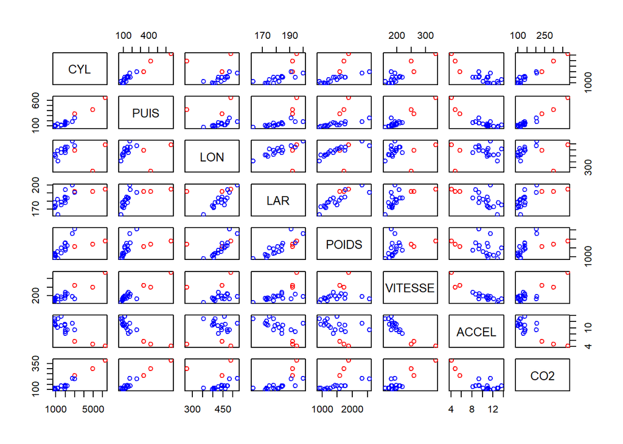

```r
#je colorie selon le groupe d'appartenance pour k=2
pairs(vt,col=c('blue','red')[km$cluster])
```

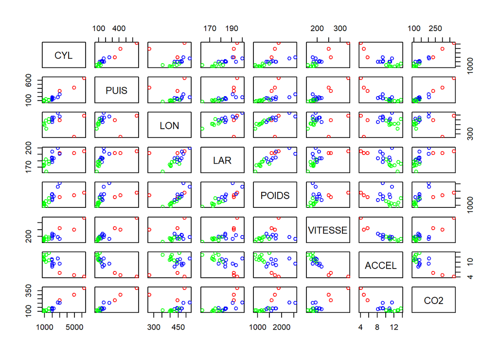

```r
#je colorie selon le groupe d'appartenance pour k=3
pairs(vt,col=c('red','blue','green')[km1$cluster])
```

En observant les résultats avec k=2, on constate que l’algorithme k-means parvient bien à capturer les relations que nous avions identifiées avec les variables CO2, vitesse, et puissance. Cependant, avec k=3, on observe des chevauchements pour l’ensemble des variables, on en conclut que certaines marques sont difficiles à distinguer en fonction de nos variables. Cela met en évidence la difficulté du choix partitionnement quand certaines observations présentent des caracteristiques similiaires importantes.

```r
#calcul des moyennes conditionnels
print(aggregate(x=vt,by=list(km$cluster),FUN=mean))
```

```
##   Group.1      CYL     PUIS      LON      LAR    POIDS  VITESSE     ACCEL
## 1       1 1654.059 130.0588 437.5882 180.3529 1455.706 189.3529 10.847059
## 2       2 4736.000 473.6667 403.3333 193.0000 1729.000 281.6667  4.866667
##        CO2
## 1 129.8824
## 2 304.3333
```

```r
print(aggregate(x=vt,by=list(km1$cluster),FUN=mean))
```

```
##   Group.1      CYL      PUIS      LON      LAR    POIDS  VITESSE     ACCEL
## 1       1 4736.000 473.66667 403.3333 193.0000 1729.000 281.6667  4.866667
## 2       2 2244.000 165.25000 466.5000 187.1250 1802.875 199.1250  9.800000
## 3       3 1129.667  98.77778 411.8889 174.3333 1147.111 180.6667 11.777778
##        CO2
## 1 304.3333
## 2 150.7500
## 3 111.3333
```

Pour k=2, on observe que le groupe 2 a une vitesse moyenne de 281.6667, tandis que le groupe 1 a une vitesse moyenne de 189.3529. Si on regarde la longueur et la largeur, on constate que les moyennes entre les deux groupes sont proches. Les moyennes conditionnelles donnent des informations sur les caractéristiques moyennes des observations de chaque cluster, cela permet de mettre en évidence les differences spécifiques entre les groupes.

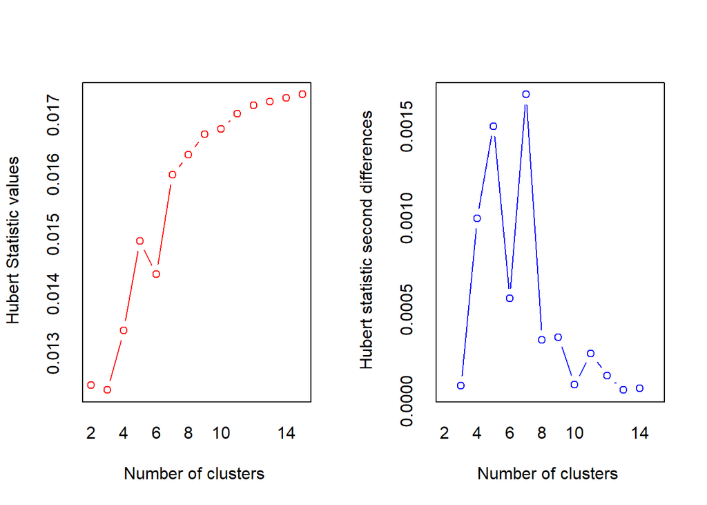

```
## *** : The Hubert index is a graphical method of determining the number of clusters.
##                 In the plot of Hubert index, we seek a significant knee that corresponds to a
##                 significant increase of the value of the measure i.e the significant peak in Hubert
##                 index second differences plot.
##
```

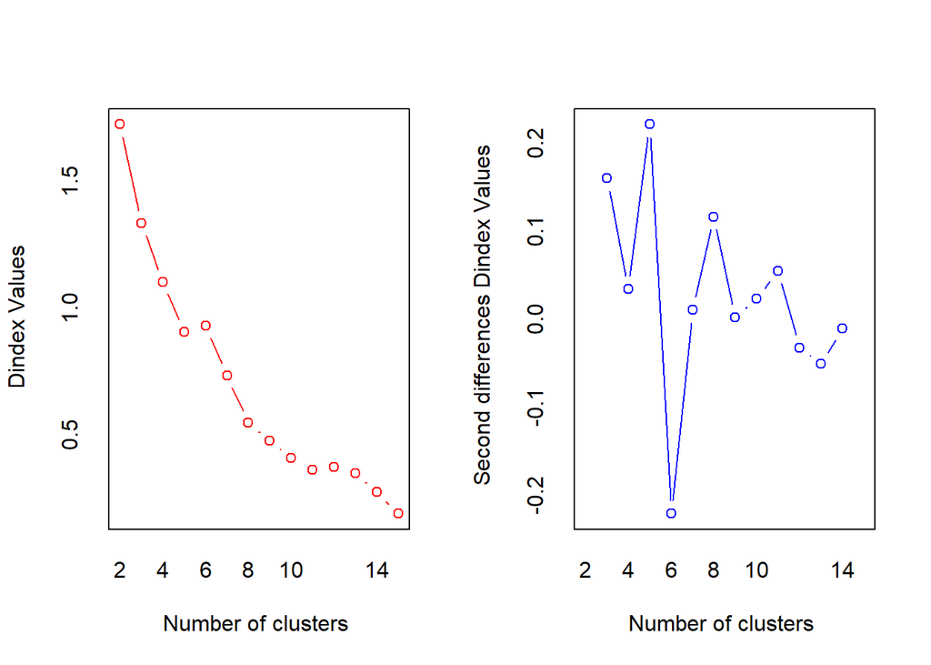

```
## *** : The D index is a graphical method of determining the number of clusters.
##                 In the plot of D index, we seek a significant knee (the significant peak in Dindex
##                 second differences plot) that corresponds to a significant increase of the value of
##                 the measure.
##
## * Among all indices:
## * 6 proposed 2 as the best number of clusters
## * 4 proposed 3 as the best number of clusters
## * 1 proposed 5 as the best number of clusters
## * 2 proposed 6 as the best number of clusters
## * 1 proposed 8 as the best number of clusters
## * 3 proposed 10 as the best number of clusters
## * 1 proposed 11 as the best number of clusters
## * 1 proposed 12 as the best number of clusters
## * 1 proposed 13 as the best number of clusters
## * 4 proposed 15 as the best number of clusters
##
##                    ***** Conclusion *****
##
## * According to the majority rule, the best number of clusters is  2
##
##
```

[output not shown]

[output cut: 87 more lines]

```r
library(NbClust)
NbClust( data=vt_stan, distance="euclidean", method="kmeans")
```

Pour déterminer explicitement le nombre optimal de clusters, on peut utiliser plusieurs indices pour différents nombres de clusters. dans notre cas La majorité d’entre eux suggèrent que 2 est le nombre optimal, avec une partition de 5 pour le groupe 1 et 15 pour le groupe 2.

##### Verfication de la qualté de la segmentation

```r
library(cluster)
metric<-silhouette(km$cluster,dist(vt_stan, "euclidean"))
print(summary(metric))
```

```
## Silhouette of 20 units in 2 clusters from silhouette.default(x = km$cluster, dist = dist(vt_stan, "euclidean")) :
##  Cluster sizes and average silhouette widths:
##        17         3
## 0.6010531 0.2187474
## Individual silhouette widths:
##     Min.  1st Qu.   Median     Mean  3rd Qu.     Max.
## -0.01243  0.44381  0.64808  0.54371  0.68995  0.70953
```

```r
metric1<-silhouette(km1$cluster,dist(vt_stan, "euclidean"))
print(summary(metric1))
```

```
## Silhouette of 20 units in 3 clusters from silhouette.default(x = km1$cluster, dist = dist(vt_stan, "euclidean")) :
##  Cluster sizes and average silhouette widths:
##         3         8         9
## 0.1093000 0.2495165 0.5094129
## Individual silhouette widths:
##    Min. 1st Qu.  Median    Mean 3rd Qu.    Max.
## -0.2045  0.2019  0.3860  0.3454  0.5298  0.6736
```

Le coefficient de silhouette varie entre [-1, 1], et plus la moyenne du coefficient est proche de 1, meilleure est la qualité de la segmentation. On observe que pour k=2, nous avons une meilleure séparation avec une moyenne de 0.54, tandis que pour k=3, la moyenne est de 0.3454. Ces résultats confirment la tendance observée précédemment, indiquant que k=2 est une segmentation de meilleure qualité pour notre ensemble de données.

##### Graphe

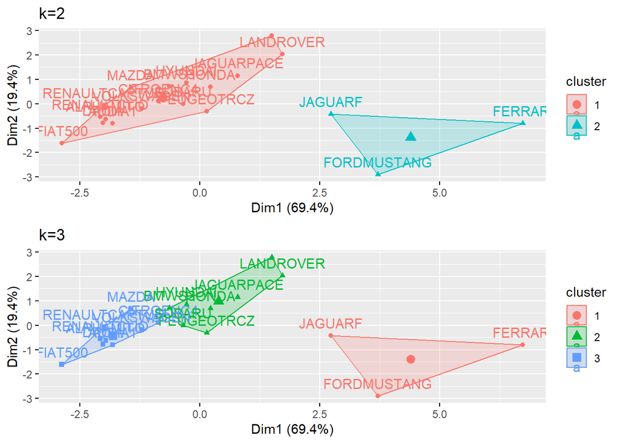

```r
k<-fviz_cluster(km ,data=vt_stan)+ggtitle("k=2")
k1<-fviz_cluster(km1, data=vt_stan)+ggtitle("k=3")
library("gridExtra")
grid.arrange(k,k1,nrow=2)
```

Avec k=2, on observe une séparation claire des groupes dans l’espace des variables. Cependant, pour k=3, on constate un chevauchement, indiquant une certaine difficulté dans la classification.

Maintenant, je vais associer chaque marque à son groupe respectif.

```r
vt$Cluster<-as.factor(km$cluster)
print(vt)
```

```
##                CYL PUIS LON LAR POIDS VITESSE ACCEL CO2 Cluster
## ALPHAMITO      875  105 406 172  1130     184  11.4  98       1
## AUDIA1         999   95 397 174  1065     186  10.9 103       1
## CITROENC4     1199  130 442 182  1280     196  10.1 115       1
## JAGUARF       2995  340 447 192  1587     260   5.7 234       2
## PEUGEOTRCZ    1997  160 428 184  1370     220   8.2 130       1
## LANDROVER     2993  256 483 191  2570     180   9.3 203       1
## RENAULTCLIO    898   90 406 173  1092     182  12.2 105       1
## BMWS3         1995  116 462 181  1570     198  11.1 109       1
## DACIA          898   90 406 173   962     175  11.1 116       1
## HYUNDAI       1995  136 447 185  1751     184  10.9 139       1
## LANCIA        2776  177 522 200  2315     193  11.5 207       1
## RENAULTCAPTUR  898   90 412 178  1180     171  13.0 113       1
## FORDMUSTANG   4951  421 272 192  1720     250   4.8 299       2
## FIAT500       1242   69 355 163   905     160  12.9 115       1
## HONDA         2199  150 472 184  1632     212   9.4 138       1
## FERRARI       6262  660 491 195  1880     335   4.1 380       2
## SUBARU        1998  147 445 178  1440     198   9.3 141       1
## MAZDA         1560  115 458 175  1490     180  13.7 138       1
## VOLKSWAGEN    1598  105 425 179  1220     192  10.7  99       1
## JAGUARPACE    1999  180 473 194  1775     208   8.7 139       1
```

Comme le nombre de cluster qu’il faut utiliser n’est pas clair j’ai utilisé un autre algorithme qui est une variante du kmeans qui attribue chaque observation un degré d’appartenance à tous les clusters, le degré est compris entre [0,1].

```r
library(e1071)
num_cl <- 2
res <- cmeans(vt_stan, num_cl, m = 2, verbose = TRUE)
```

```
## Iteration:   1, Error:  3.8146194187
## Iteration:   2, Error:  3.7626422366
## Iteration:   3, Error:  3.6387150193
## Iteration:   4, Error:  3.3512232820
## Iteration:   5, Error:  3.1263953478
## Iteration:   6, Error:  3.0604687202
## Iteration:   7, Error:  3.0363238490
## Iteration:   8, Error:  3.0220100084
## Iteration:   9, Error:  3.0127547089
## Iteration:  10, Error:  3.0068151979
## Iteration:  11, Error:  3.0030851015
## Iteration:  12, Error:  3.0007957621
## Iteration:  13, Error:  2.9994197457
## Iteration:  14, Error:  2.9986072095
## Iteration:  15, Error:  2.9981342713
## Iteration:  16, Error:  2.9978621196
## Iteration:  17, Error:  2.9977068940
## Iteration:  18, Error:  2.9976189603
## Iteration:  19, Error:  2.9975694049
## Iteration:  20, Error:  2.9975415873
## Iteration:  21, Error:  2.9975260183
## Iteration:  22, Error:  2.9975173240
## Iteration:  23, Error:  2.9975124768
## Iteration:  24, Error:  2.9975097779
## Iteration:  25, Error:  2.9975082765
## Iteration:  26, Error:  2.9975074419
## Iteration:  27, Error:  2.9975069781
## Iteration:  28, Error:  2.9975067206
## Iteration:  29, Error:  2.9975065776
## Iteration:  30, Error:  2.9975064982
## Iteration:  31 converged, Error:  2.9975064541
```

```r
# les centres des clusters
cat("Centres des clusters :\n")
```

```
## Centres des clusters :
```

```r
## Centres des clusters :
print(res$centers)
```

```
##          CYL      PUIS          LON        LAR      POIDS    VITESSE      ACCEL
## 1 -0.4322953 -0.423642 -0.062313558 -0.4114578 -0.3666628 -0.3544864  0.3903694
## 2  1.3665413  1.443939  0.004785344  1.1226731  0.8398773  1.3026945 -1.3473986
##          CO2
## 1 -0.4533454
## 2  1.4775028
```

```r
#  les degrés d'appartenance
cat("Degrés d'appartenance des points aux clusters :\n")
```

```
## Degrés d'appartenance des points aux clusters :
```

```r
## Degrés d'appartenance des points aux clusters :
print(res$membership)
```

```
##                        1           2
## ALPHAMITO     0.95887976 0.041120244
## AUDIA1        0.95775467 0.042245326
## CITROENC4     0.97762186 0.022378137
## JAGUARF       0.08321521 0.916784786
## PEUGEOTRCZ    0.83286910 0.167130895
## LANDROVER     0.41908122 0.580918779
## RENAULTCLIO   0.95634995 0.043650051
## BMWS3         0.94948236 0.050517636
## DACIA         0.94760937 0.052390627
## HYUNDAI       0.89806387 0.101936132
## LANCIA        0.47646018 0.523539823
## RENAULTCAPTUR 0.95774902 0.042250984
## FORDMUSTANG   0.22241788 0.777582118
## FIAT500       0.86058246 0.139417539
## HONDA         0.82425498 0.175745021
## FERRARI       0.18597205 0.814027946
## SUBARU        0.94665284 0.053347155
## MAZDA         0.93713090 0.062869096
## VOLKSWAGEN    0.99004507 0.009954934
## JAGUARPACE    0.63378705 0.366212950
```

## Classification avec la Methode de WARD :

C’est une methode qui va regrouper les observations sur le critere de la distance separant les points.

### Calcul de la matrice de distance euclidienne :

```r
# matrice de distance euclidienne entre les observations
distance_matrix <- dist(vt_stan)
```

### Application de la méthode de Ward pour la classification hiérarchique :

```r
#Application de la méthode de Ward pour la classification hiérarchique pour minimiser la variance intra-cluster.
hierarchical_model <- hclust(distance_matrix, method = "ward.D2")
```

### Tracé du dendogramme :

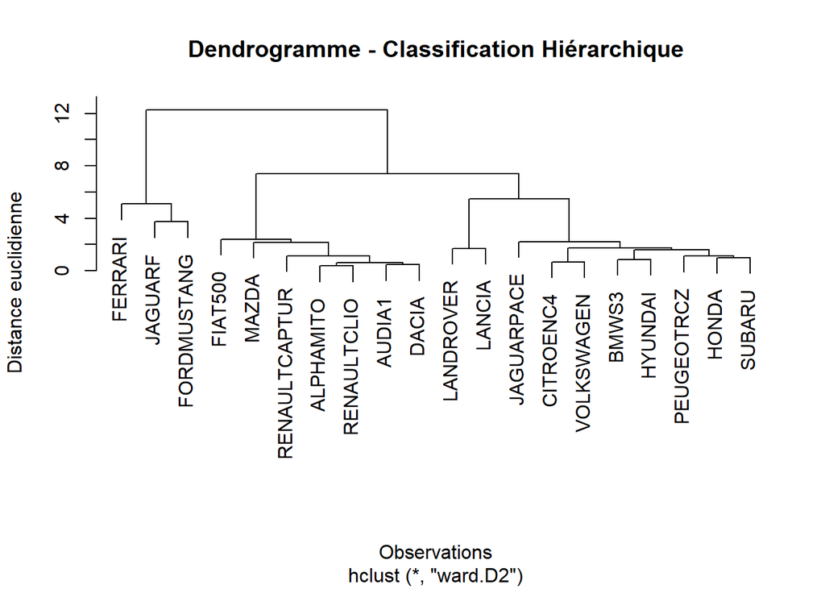

```r
plot(hierarchical_model, main = "Dendrogramme - Classification Hiérarchique", xlab = "Observations", ylab = "Distance euclidienne", sub = NULL)
```

On observe qu’à la hauteur 12 du dendogramme, il divise les observations en 2, c’est le resultat qu’on avait avec la methode kmeans pour k=2. Ensuite à la hauteur 7 pour la partie 2, on a egalement une division des observations en 2. Pour la premiere classe on obtient le meme partinnionnement qu’on avait avec kmeans. Pour trouver le nombre optimal de cluster on peut visualsier l’inertie en fonction du nombre de clusters.

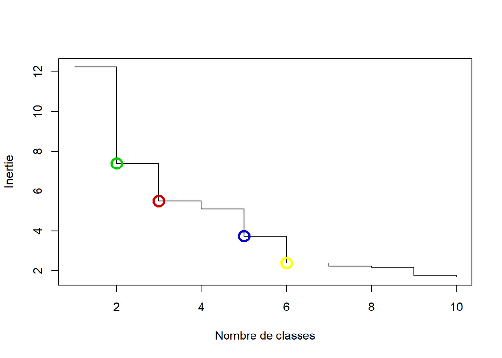

```r
# je coupe le dendogramme en fonction du nombre de classes que je souhaite
cut_dendrogram <- cutree(hierarchical_model, k = 2)


# les étiquettes de classe
df_with_labels <- cbind(df, Cluster = cut_dendrogram)
#je calcul l'inertie

inertie <- sort(hierarchical_model$height, decreasing = TRUE)


plot(inertie[1:10], type = "s", xlab = "Nombre de classes", ylab = "Inertie")
points(c(2, 3, 5,6), inertie[c(2, 3, 5,6)], col = c("green3", "red3", "blue3","yellow"), cex = 2, lwd = 3)
```

On observe donc 4 sauts qui sont assez elevés.

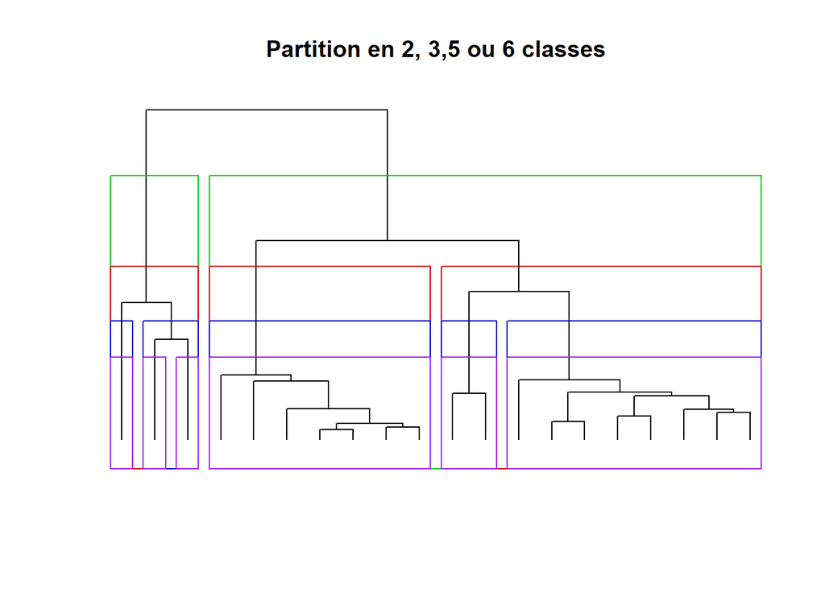

```r
plot(hierarchical_model, labels = FALSE, main = "Partition en 2, 3,5 ou 6 classes", xlab = "", ylab = "", sub = "", axes = FALSE, hang = -1)
rect.hclust(hierarchical_model, 2, border = "green3")
rect.hclust(hierarchical_model, 3, border = "red3")
rect.hclust(hierarchical_model, 5, border = "blue3")
rect.hclust(hierarchical_model, 6, border = "purple")
```

Suite à l’analyse hiérarchique, On a observé 4 sauts( 2,3,5 et 6), le saut le plus eleveé est le partitionnement pour en 2 clusters, qui montre une meilleur cohesion.En utilisant l’indice de silhouette, on a que le nombre optimal de clusters est effectivement 2. En conclsuion le choix du cluster est tres flou, la meilleure solution serait d’avoir une idée metier des experts du domaine ou d’explorer davantage la nature des données.